# Assignment 3

** PART 1 **

```r
library(readr)
AmesTrain12 <- read_csv("AmesTrain12.csv")
View(AmesTrain12)
HomeData = select_if(AmesTrain12, is.numeric)
HomeData = select(HomeData, -c(Order))
View(HomeData)
```

** The first thing we did with our data was to remove obviously correlated predictor variables and called this dataset HomeData2, after this we ran backwards elim, forwards elim, and step-wise regression on the resulting data. All three gave us the same Cpvalue of 14.651 and ended with the same result.

Then we decided to create another model from HomeData2 predictor variables. We then saw that the vif of the predictor variables were not extremely high. We took out predictor variables that did not have a significant p-value, then reran the t-test with our new model, and continued this until all predictors had a significant p-value. We called this model HouseData4. We then ran step-wise regression, forwards elim, and backwards elim on this model. The Cpvalue given was 11.000 for all three, because this cp-value was smaller than the first model’s cp-value, we decided this model was the best and named it BasicModel. **

```r
HomeData2 = select(HomeData, -c(FirstSF, SecondSF, GarageCars, BasementFinSF, BasementUnFinSF, Quality, Condition))


# Variables Removed:
# All Categorical Variable, GarageCars, FirstSF, Second SF, BasementFinSF, BasementUnfinSF, Quality and Condition
#
# (Including the #Car garage, can also remove it due to correlation with GarageSF)
#
# (FirstSF, Second SF) because they are related to GroundSF
#
# (BasementFinSF and BasementUnfinSF) because they are related to BasementSF
#
# Variables Included:
# Price, LotFrontage, LotArea, Quality, Condition, YearBuilt, YearRemodel, BasementSF, Full Bath, HalfBath, Bedroom, TotalRooms, Fireplaces, GarageCars GarageSF, WoodDeckSF, OpenPorchSF, EnclosedPorchSF, ScreenPorchSF,  BasementHBath, BasementFBath
```

```r
HomeData3 = select(HomeData2, -c(BasementHBath,FullBath,HalfBath,WoodDeckSF,OpenPorchSF,EnclosedPorchSF,ScreenPorchSF))

HomeData3Model=lm(Price~.,data=HomeData3)

summary(HomeData3Model)
```

```
##
## Call:
## lm(formula = Price ~ ., data = HomeData3)
##
## Residuals:
##      Min       1Q   Median       3Q      Max
## -140.645  -18.924   -1.302   15.881  166.684
##
## Coefficients:
##                 Estimate Std. Error t value Pr(>|t|)
## (Intercept)   -2.024e+03  1.473e+02 -13.738  < 2e-16 ***
## LotFrontage    1.461e-01  4.217e-02   3.464  0.00057 ***
## LotArea        3.331e-04  1.083e-04   3.074  0.00221 **
## YearBuilt      5.225e-01  5.922e-02   8.824  < 2e-16 ***
## YearRemodel    5.039e-01  8.506e-02   5.924 5.35e-09 ***
## BasementSF     4.134e-02  4.269e-03   9.683  < 2e-16 ***
## GroundSF       6.007e-02  5.710e-03  10.520  < 2e-16 ***
## BasementFBath  8.190e+00  2.823e+00   2.901  0.00386 **
## Bedroom       -1.024e+01  2.424e+00  -4.224 2.78e-05 ***
## TotalRooms     3.104e+00  1.824e+00   1.702  0.08926 .
## Fireplaces     1.100e+01  2.620e+00   4.197 3.13e-05 ***
## GarageSF       5.866e-02  7.912e-03   7.414 4.28e-13 ***
## ---
## Signif. codes:  0 '***' 0.001 '**' 0.01 '*' 0.05 '.' 0.1 ' ' 1
##
## Residual standard error: 32.75 on 588 degrees of freedom
## Multiple R-squared:  0.8161, Adjusted R-squared:  0.8127
## F-statistic: 237.3 on 11 and 588 DF,  p-value: < 2.2e-16
```

```r
HomeData4 = select(HomeData3, -c(TotalRooms))

HomeData4Model=lm(Price~.,data=HomeData4)

summary(HomeData4Model)
```

```
##
## Call:
## lm(formula = Price ~ ., data = HomeData4)
##
## Residuals:
##     Min      1Q  Median      3Q     Max
## -141.62  -19.02   -1.34   15.64  167.03
##
## Coefficients:
##                 Estimate Std. Error t value Pr(>|t|)
## (Intercept)   -2.021e+03  1.475e+02 -13.701  < 2e-16 ***
## LotFrontage    1.505e-01  4.216e-02   3.571 0.000385 ***
## LotArea        3.266e-04  1.085e-04   3.012 0.002710 **
## YearBuilt      5.179e-01  5.925e-02   8.741  < 2e-16 ***
## YearRemodel    5.102e-01  8.512e-02   5.994 3.57e-09 ***
## BasementSF     4.131e-02  4.276e-03   9.661  < 2e-16 ***
## GroundSF       6.628e-02  4.401e-03  15.060  < 2e-16 ***
## BasementFBath  7.891e+00  2.822e+00   2.796 0.005348 **
## Bedroom       -8.435e+00  2.184e+00  -3.863 0.000125 ***
## Fireplaces     1.104e+01  2.624e+00   4.208 2.98e-05 ***
## GarageSF       5.837e-02  7.923e-03   7.368 5.90e-13 ***
## ---
## Signif. codes:  0 '***' 0.001 '**' 0.01 '*' 0.05 '.' 0.1 ' ' 1
##
## Residual standard error: 32.8 on 589 degrees of freedom
## Multiple R-squared:  0.8152, Adjusted R-squared:  0.8121
## F-statistic: 259.9 on 10 and 589 DF,  p-value: < 2.2e-16
```

```r
Full = lm(Price~.,data=HomeData4)

MSE2 = (summary(HomeData4Model)$sigma)^2

none=lm(Price~1, data=HomeData4)

step(none,scope=list(upper=HomeData4Model), scale=MSE2)
```

```
## Start:  AIC=2589.72
## Price ~ 1
##
##                 Df Sum of Sq     RSS     Cp
## + GroundSF       1   1620095 1809691 1086.0
## + GarageSF       1   1465153 1964634 1230.0
## + BasementSF     1   1410220 2019567 1281.0
## + YearBuilt      1   1147038 2282749 1525.6
## + YearRemodel    1   1103893 2325893 1565.7
## + Fireplaces     1    797766 2632020 1850.3
## + LotArea        1    193323 3236464 2412.0
## + BasementFBath  1    164761 3265026 2438.6
## + Bedroom        1    141068 3288719 2460.6
## + LotFrontage    1    106823 3322963 2492.4
## <none>                       3429786 2589.7
##
## Step:  AIC=1085.97
## Price ~ GroundSF
##
##                 Df Sum of Sq     RSS      Cp
## + YearBuilt      1    724437 1085253  414.66
## + BasementSF     1    618674 1191017  512.96
## + YearRemodel    1    479217 1330474  642.57
## + GarageSF       1    472845 1336846  648.50
## + BasementFBath  1    223936 1585755  879.84
## + Bedroom        1    198118 1611573  903.83
## + Fireplaces     1    105610 1704081  989.81
## + LotFrontage    1     30647 1779043 1059.48
## + LotArea        1     20725 1788966 1068.71
## <none>                       1809691 1085.97
## - GroundSF       1   1620095 3429786 2589.72
##
## Step:  AIC=414.66
## Price ~ GroundSF + YearBuilt
##
##                 Df Sum of Sq     RSS      Cp
## + BasementSF     1    227723  857531  205.01
## + GarageSF       1    146924  938329  280.11
## + Bedroom        1     87390  997864  335.44
## + BasementFBath  1     75011 1010243  346.94
```

[output cut: 125 more lines]

```
## Price ~ GroundSF + YearBuilt + BasementSF + GarageSF + YearRemodel +
##     Fireplaces + Bedroom + LotFrontage + LotArea + BasementFBath
##
##                 Df Sum of Sq    RSS      Cp
## <none>                       633726  11.000
## - BasementFBath  1      8409 642136  16.816
## - LotArea        1      9759 643485  18.070
## - LotFrontage    1     13719 647446  21.751
## - Bedroom        1     16054 649781  23.921
## - Fireplaces     1     19049 652775  26.705
## - YearRemodel    1     38656 672382  44.928
## - GarageSF       1     58402 692128  63.280
## - YearBuilt      1     82206 715932  85.404
## - BasementSF     1    100413 734139 102.326
## - GroundSF       1    244023 877749 235.801
```

```
##
## Call:
## lm(formula = Price ~ GroundSF + YearBuilt + BasementSF + GarageSF +
##     YearRemodel + Fireplaces + Bedroom + LotFrontage + LotArea +
##     BasementFBath, data = HomeData4)
##
## Coefficients:
##   (Intercept)       GroundSF      YearBuilt     BasementSF       GarageSF
##    -2.021e+03      6.628e-02      5.179e-01      4.131e-02      5.837e-02
##   YearRemodel     Fireplaces        Bedroom    LotFrontage        LotArea
##     5.102e-01      1.104e+01     -8.435e+00      1.505e-01      3.266e-04
## BasementFBath
##     7.891e+00
```

```r
BasicModel=lm(Price~GroundSF+YearBuilt+BasementSF+GarageSF+YearRemodel+Fireplaces+Bedroom+LotFrontage+LotArea+BasementFBath, data=HomeData4)
summary(BasicModel)
```

```
##
## Call:
## lm(formula = Price ~ GroundSF + YearBuilt + BasementSF + GarageSF +
##     YearRemodel + Fireplaces + Bedroom + LotFrontage + LotArea +
##     BasementFBath, data = HomeData4)
##
## Residuals:
##     Min      1Q  Median      3Q     Max
## -141.62  -19.02   -1.34   15.64  167.03
##
## Coefficients:
##                 Estimate Std. Error t value Pr(>|t|)
## (Intercept)   -2.021e+03  1.475e+02 -13.701  < 2e-16 ***
## GroundSF       6.628e-02  4.401e-03  15.060  < 2e-16 ***
## YearBuilt      5.179e-01  5.925e-02   8.741  < 2e-16 ***
## BasementSF     4.131e-02  4.276e-03   9.661  < 2e-16 ***
## GarageSF       5.837e-02  7.923e-03   7.368 5.90e-13 ***
## YearRemodel    5.102e-01  8.512e-02   5.994 3.57e-09 ***
## Fireplaces     1.104e+01  2.624e+00   4.208 2.98e-05 ***
## Bedroom       -8.435e+00  2.184e+00  -3.863 0.000125 ***
## LotFrontage    1.505e-01  4.216e-02   3.571 0.000385 ***
## LotArea        3.266e-04  1.085e-04   3.012 0.002710 **
## BasementFBath  7.891e+00  2.822e+00   2.796 0.005348 **
## ---
## Signif. codes:  0 '***' 0.001 '**' 0.01 '*' 0.05 '.' 0.1 ' ' 1
##
## Residual standard error: 32.8 on 589 degrees of freedom
## Multiple R-squared:  0.8152, Adjusted R-squared:  0.8121
## F-statistic: 259.9 on 10 and 589 DF,  p-value: < 2.2e-16
```

```r
vif(BasicModel)
```

```
##      GroundSF     YearBuilt    BasementSF      GarageSF   YearRemodel
##      2.723609      1.910304      1.580735      1.633125      1.780334
##    Fireplaces       Bedroom   LotFrontage       LotArea BasementFBath
##      1.442517      1.766894      1.044906      1.131601      1.229621
```

** All of the predictors in the model have a significant p-value.

None of the vif values of the individual predictors are extremely high, the highest being GroundSF with a vif of 2.72

The low vif values of the predictors tell us that no individual predictors have a standard error that is inflated by a high factor, therefore no predictor’s t-value and p-value were majorly affected by multicollinearity. **

** PART 2 **

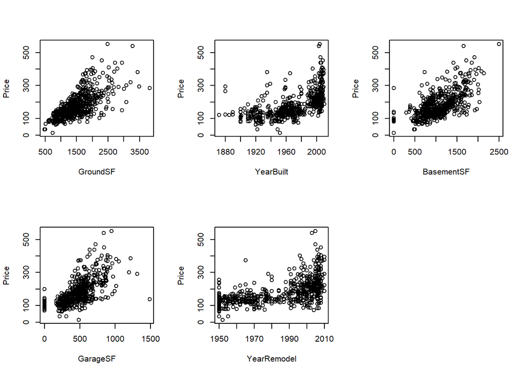

```r
par(mfrow=c(2,3))
plot(Price ~ GroundSF+YearBuilt+BasementSF+GarageSF+YearRemodel, data=HomeData)

par(mfrow=c(2,3))
```

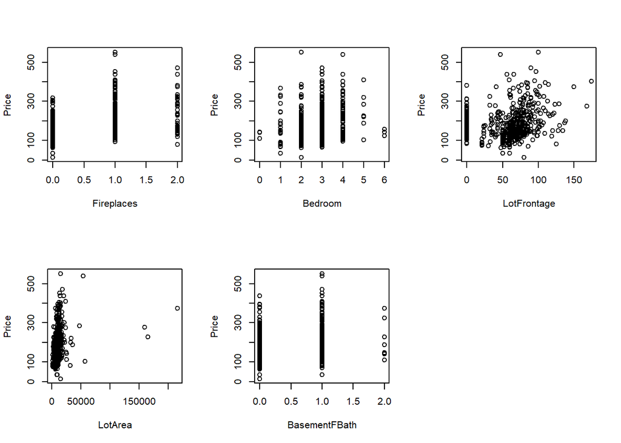

```r
plot(Price ~Fireplaces+Bedroom+LotFrontage+LotArea+BasementFBath, data=HomeData)
```

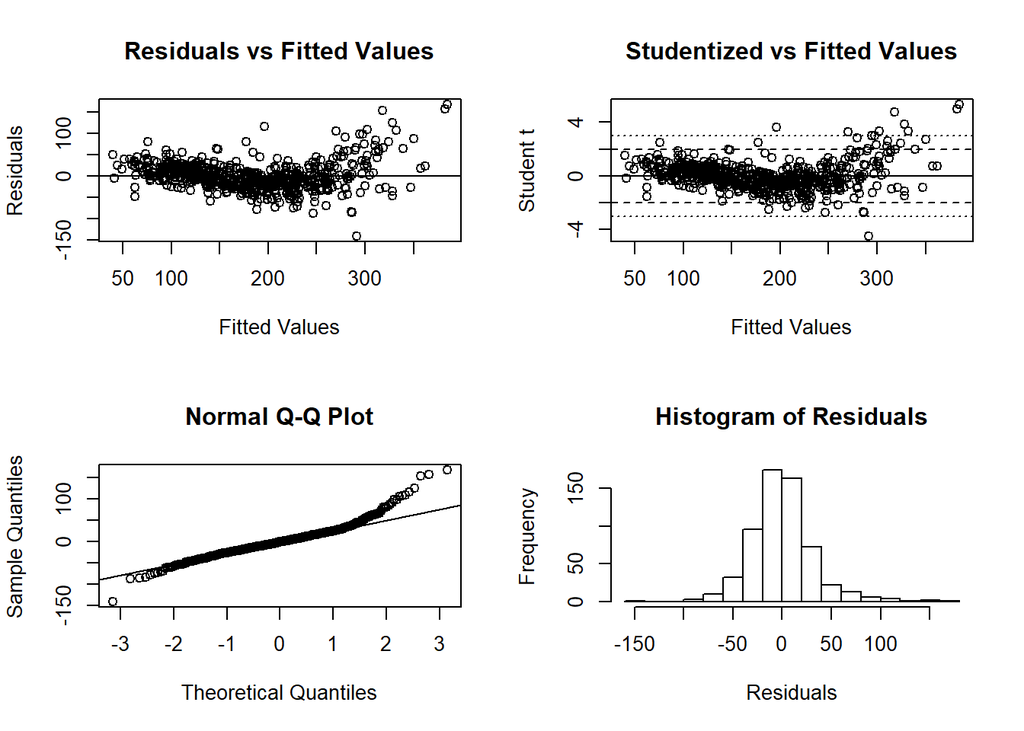

```r
r_student <- rstudent(BasicModel)

par(mfrow=c(2,2))
plot(BasicModel$residuals~BasicModel$fitted.values, main="Residuals vs Fitted Values", xlab="Fitted Values", ylab="Residuals")
abline(0,0)
plot(r_student ~ BasicModel$fitted.values,  main="Studentized vs Fitted Values", xlab="Fitted Values", ylab="Student t")
abline(0,0)
abline(2,0, lty=2)
abline(-2,0, lty=2)
abline(3,0, lty=3)
abline(-3,0, lty=3)
qqnorm(BasicModel$residuals)
qqline(BasicModel$residuals)
hist(BasicModel$residuals, breaks=12,main="Histogram of Residuals", xlab="Residuals")
```

In terms of zero disturbance term, the distribution of the error is centered at zero. In other words, points are randomly scattered above and below the line. This can be confirmed by Residuals vs Fitted Plot and the histogram of residuals.

The residual vs fitted plot also tells us about the constant variance, which is not the case for our model, since residuals respond to changes in fitted values. There is some pattern, as shown by curved shape of distribution. Therefore, we cannot assume homoskedasticity, yet this issue is expected to be addressed in a fancier model that will appear in the Part 3, through transformations and other relevant techniques.

When it comes to normality, we could merely refer to the histogram of residuals to see if the normality is met. However, histogram might sometimes not be informative if the number of bins is set inappropriately, usually with the small sample size. For more circumvent inspection, use a normal quantile plot of the residuals.

The histogram of residuals indicates that residuals seems closely normally distributed, yet normal Q-Q plot displays a little right skewness in the distribution of residuals.

We will also address this issue by transformation, in the latter part of this assignment.

```r
max(abs(r_student))
```

```
## [1] 5.30741
```

```r
max_residual_indx <- which.max(abs(r_student))
max_residual_indx
```

```
## 377
## 377
```

```r
outlier_candidates <- sum(abs(r_student) > 3)
outlier_candidates
```

```
## [1] 11
```

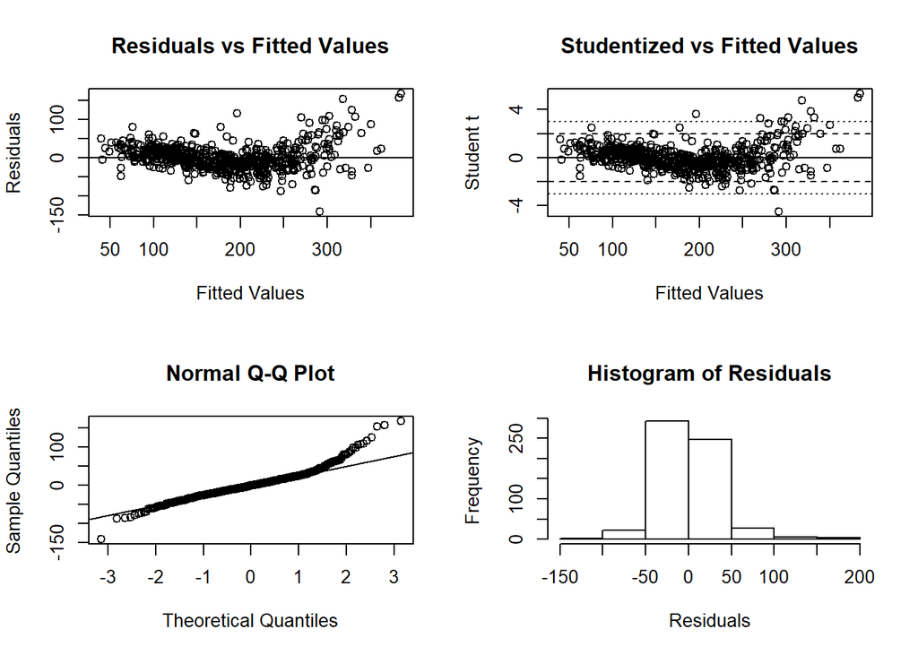

```r
r_student <- rstudent(BasicModel)

par(mfrow=c(2,2))
plot(BasicModel$residuals~BasicModel$fitted.values, main="Residuals vs Fitted Values", xlab="Fitted Values", ylab="Residuals")
abline(0,0)
plot(r_student ~ BasicModel$fitted.values,  main="Studentized vs Fitted Values", xlab="Fitted Values", ylab="Student t")
abline(0,0)
abline(2,0, lty=2)
abline(-2,0, lty=2)
abline(3,0, lty=3)
abline(-3,0, lty=3)
qqnorm(BasicModel$residuals)
qqline(BasicModel$residuals)
hist(BasicModel$residuals, main="Histogram of Residuals", xlab="Residuals")
```

In terms of zero disturbance term, the distribution of the error is centered at zero. In other words, points are randomly scattered above and below the line. This can be confirmed by Residuals vs Fitted Plot and the histogram of residuals.

The residual vs fitted plot also tells us about the constant variance, which is not the case for our model, since residuals respond to changes in fitted values. There is some pattern, as shown by curved shape of distribution. Therefore, we cannot assume homoskedasticity, yet this issue is expected to be addressed in a fancier model that will appear in the Part 3, through transformations and other relevant techniques.

```r
max(abs(r_student))
```

```
## [1] 5.30741
```

```r
max_residual_indx <- which.max(abs(r_student))
max_residual_indx
```

```
## 377
## 377
```

```r
outlier_candidates <- sum(abs(r_student) > 3)
outlier_candidates
```

```
## [1] 11
```

When it comes to normality, we could merely refer to the histogram of residuals to see if the normality is met. However, histogram might sometimes not be informative if the number of bins is set inappropriately, usually with the small sample size. For more circumvent inspection, use a normal quantile plot of the residuals.

The histogram of residuals indicates that residuals seems closely normally distributed, yet normal Q-Q plot displays a little right skewness in the distribution of residuals.

We will also address this issue by transformation, in the latter part of this assignment.

** PART 3 **

We decided to create two summary comparison variables on the basis of their meaning. We created one summary variable which encapsulated all the different types of bathrooms, multiplying the half baths by .5 to represent their reduced value. We created an additional summary variable which encapsulated all the different porch square footages. We reasoned that the combination of them was sensible, as they were effectively divided by category and we combined them to avoid their more categorical nature.

```r
modelFancy = lm(Price~I(BasementFBath+BasementHBath*.5+FullBath+HalfBath*.5)+I(WoodDeckSF + OpenPorchSF + EnclosedPorchSF + ScreenPorchSF)+LotFrontage + LotArea + I(1/(2019-YearBuilt)) + I(1/(2019-YearRemodel)) + BasementSF + GroundSF + Bedroom + TotalRooms + GarageSF, data=HomeData)
summary(modelFancy)
```

```
##
## Call:
## lm(formula = Price ~ I(BasementFBath + BasementHBath * 0.5 +
##     FullBath + HalfBath * 0.5) + I(WoodDeckSF + OpenPorchSF +
##     EnclosedPorchSF + ScreenPorchSF) + LotFrontage + LotArea +
##     I(1/(2019 - YearBuilt)) + I(1/(2019 - YearRemodel)) + BasementSF +
##     GroundSF + Bedroom + TotalRooms + GarageSF, data = HomeData)
##
## Residuals:
##      Min       1Q   Median       3Q      Max
## -130.820  -19.300   -0.156   16.325  162.593
##
## Coefficients:
##                                                                      Estimate
## (Intercept)                                                        -2.901e+01
## I(BasementFBath + BasementHBath * 0.5 + FullBath + HalfBath * 0.5)  8.945e+00
## I(WoodDeckSF + OpenPorchSF + EnclosedPorchSF + ScreenPorchSF)       3.716e-02
## LotFrontage                                                         8.111e-02
## LotArea                                                             4.436e-04
## I(1/(2019 - YearBuilt))                                             7.111e+02
## I(1/(2019 - YearRemodel))                                           2.837e+02
## BasementSF                                                          4.195e-02
## GroundSF                                                            6.115e-02
## Bedroom                                                            -7.105e+00
## TotalRooms                                                         -7.419e-01
## GarageSF                                                            5.357e-02
##                                                                    Std. Error
## (Intercept)                                                         7.256e+00
## I(BasementFBath + BasementHBath * 0.5 + FullBath + HalfBath * 0.5)  2.436e+00
## I(WoodDeckSF + OpenPorchSF + EnclosedPorchSF + ScreenPorchSF)       8.795e-03
## LotFrontage                                                         4.174e-02
## LotArea                                                             1.070e-04
## I(1/(2019 - YearBuilt))                                             1.012e+02
## I(1/(2019 - YearRemodel))                                           9.035e+01
## BasementSF                                                          4.156e-03
## GroundSF                                                            5.663e-03
## Bedroom                                                             2.383e+00
## TotalRooms                                                          1.805e+00
## GarageSF                                                            7.855e-03
##                                                                    t value
```

[output cut: 29 more lines]

```
## LotFrontage                                                        .
## LotArea                                                            ***
## I(1/(2019 - YearBuilt))                                            ***
## I(1/(2019 - YearRemodel))                                          **
## BasementSF                                                         ***
## GroundSF                                                           ***
## Bedroom                                                            **
## TotalRooms
## GarageSF                                                           ***
## ---
## Signif. codes:  0 '***' 0.001 '**' 0.01 '*' 0.05 '.' 0.1 ' ' 1
##
## Residual standard error: 32.31 on 588 degrees of freedom
## Multiple R-squared:  0.821,  Adjusted R-squared:  0.8177
## F-statistic: 245.2 on 11 and 588 DF,  p-value: < 2.2e-16
```

The summary below shows that the TotalRooms variable does not have a statistically significant impact on the model. It was therefore eliminated from the model.

```r
modelFancy = lm(Price~I(BasementFBath+BasementHBath*.5+FullBath+HalfBath*.5)+I(WoodDeckSF + OpenPorchSF + EnclosedPorchSF + ScreenPorchSF)+LotFrontage + LotArea + I(1/(2019-YearBuilt)) + I(1/(2019-YearRemodel)) + BasementSF + GroundSF + Bedroom + GarageSF, data=HomeData)
summary(modelFancy)
```

```
##
## Call:
## lm(formula = Price ~ I(BasementFBath + BasementHBath * 0.5 +
##     FullBath + HalfBath * 0.5) + I(WoodDeckSF + OpenPorchSF +
##     EnclosedPorchSF + ScreenPorchSF) + LotFrontage + LotArea +
##     I(1/(2019 - YearBuilt)) + I(1/(2019 - YearRemodel)) + BasementSF +
##     GroundSF + Bedroom + GarageSF, data = HomeData)
##
## Residuals:
##      Min       1Q   Median       3Q      Max
## -130.666  -19.071   -0.241   16.453  162.440
##
## Coefficients:
##                                                                      Estimate
## (Intercept)                                                        -3.033e+01
## I(BasementFBath + BasementHBath * 0.5 + FullBath + HalfBath * 0.5)  8.971e+00
## I(WoodDeckSF + OpenPorchSF + EnclosedPorchSF + ScreenPorchSF)       3.713e-02
## LotFrontage                                                         8.012e-02
## LotArea                                                             4.446e-04
## I(1/(2019 - YearBuilt))                                             7.091e+02
## I(1/(2019 - YearRemodel))                                           2.824e+02
## BasementSF                                                          4.205e-02
## GroundSF                                                            5.964e-02
## Bedroom                                                            -7.558e+00
## GarageSF                                                            5.376e-02
##                                                                    Std. Error
## (Intercept)                                                         6.500e+00
## I(BasementFBath + BasementHBath * 0.5 + FullBath + HalfBath * 0.5)  2.433e+00
## I(WoodDeckSF + OpenPorchSF + EnclosedPorchSF + ScreenPorchSF)       8.788e-03
## LotFrontage                                                         4.164e-02
## LotArea                                                             1.069e-04
## I(1/(2019 - YearBuilt))                                             1.010e+02
## I(1/(2019 - YearRemodel))                                           9.023e+01
## BasementSF                                                          4.146e-03
## GroundSF                                                            4.318e-03
## Bedroom                                                             2.111e+00
## GarageSF                                                            7.836e-03
##                                                                    t value
## (Intercept)                                                         -4.667
## I(BasementFBath + BasementHBath * 0.5 + FullBath + HalfBath * 0.5)   3.687
```

[output cut: 24 more lines]

```
## I(WoodDeckSF + OpenPorchSF + EnclosedPorchSF + ScreenPorchSF)      ***
## LotFrontage                                                        .
## LotArea                                                            ***
## I(1/(2019 - YearBuilt))                                            ***
## I(1/(2019 - YearRemodel))                                          **
## BasementSF                                                         ***
## GroundSF                                                           ***
## Bedroom                                                            ***
## GarageSF                                                           ***
## ---
## Signif. codes:  0 '***' 0.001 '**' 0.01 '*' 0.05 '.' 0.1 ' ' 1
##
## Residual standard error: 32.29 on 589 degrees of freedom
## Multiple R-squared:  0.821,  Adjusted R-squared:  0.8179
## F-statistic: 270.1 on 10 and 589 DF,  p-value: < 2.2e-16
```

```r
all = regsubsets(Price~I(BasementFBath+BasementHBath*.5+FullBath+HalfBath*.5)+I(WoodDeckSF + OpenPorchSF + EnclosedPorchSF + ScreenPorchSF)+LotFrontage + LotArea + I(1/(2019-YearBuilt)) + I(1/(2019-YearRemodel)) + BasementSF + GroundSF + Bedroom + GarageSF, data=HomeData, nbest = 2, nvmax=12)
ShowSubsets(all)
```

|  | I(BasementFBath + BasementHBath * 0.5 + FullBath + HalfBath * 0.5) | I(WoodDeckSF + OpenPorchSF + EnclosedPorchSF + ScreenPorchSF) | LotFrontage | LotArea | I(1/(2019 - YearBuilt)) | I(1/(2019 - YearRemodel)) | BasementSF | GroundSF | Bedroom | GarageSF | Rsq | adjRsq | Cp |
| --- | --- | --- | --- | --- | --- | --- | --- | --- | --- | --- | --- | --- | --- |
| 1 ( 1 ) |  |  |  |  |  |  |  | * |  |  | 47.24 | 47.15 | 1139.96 |
| 1 ( 2 ) | * |  |  |  |  |  |  |  |  |  | 43.69 | 43.59 | 1256.71 |
| 2 ( 1 ) |  |  |  |  | * |  |  | * |  |  | 71.11 | 71.02 | 356.34 |
| 2 ( 2 ) |  |  |  |  |  |  | * | * |  |  | 65.27 | 65.16 | 548.49 |
| 3 ( 1 ) |  |  |  |  | * |  | * | * |  |  | 77.20 | 77.08 | 158.26 |
| 3 ( 2 ) |  |  |  |  |  | * | * | * |  |  | 75.30 | 75.18 | 220.53 |
| 4 ( 1 ) |  |  |  |  | * |  | * | * |  | * | 79.21 | 79.07 | 93.95 |
| 4 ( 2 ) |  | * |  |  | * |  | * | * |  |  | 78.34 | 78.20 | 122.59 |
| 5 ( 1 ) |  | * |  |  | * |  | * | * |  | * | 80.10 | 79.93 | 66.70 |
| 5 ( 2 ) |  |  |  | * | * |  | * | * |  | * | 79.94 | 79.77 | 72.04 |

[output cut: 9 more lines]

A regsubsets test was performed on the remaining model, it showed that the lowest Mallow’s CP and highest Adjusted RSQ was obtained from using all of the variables.

** PART 4 **

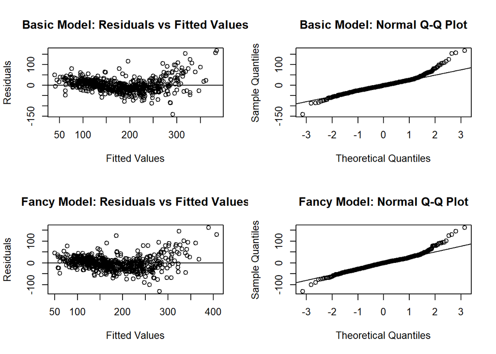

```r
par(mfrow=c(2,2))
plot(BasicModel$residuals ~ BasicModel$fitted.values, main="Basic Model: Residuals vs Fitted Values", xlab="Fitted Values", ylab="Residuals")
abline(0,0)
qqnorm(BasicModel$residuals, main="Basic Model: Normal Q-Q Plot")
qqline(BasicModel$residuals)
plot(modelFancy$residuals ~ modelFancy$fitted.values, main="Fancy Model: Residuals vs Fitted Values", xlab="Fitted Values", ylab="Residuals")
abline(0,0)
qqnorm(modelFancy$residuals, main="Fancy Model: Normal Q-Q Plot")
qqline(modelFancy$residuals)
```

The above plots are residuals vs fitted plot and Q-Q plot, each from the basic model and the fancy model. There seem little changes or improvements in fit, just by visual inspection, but the actual distribution of residuals in the fancy model has less curvature with less residuals squared value.

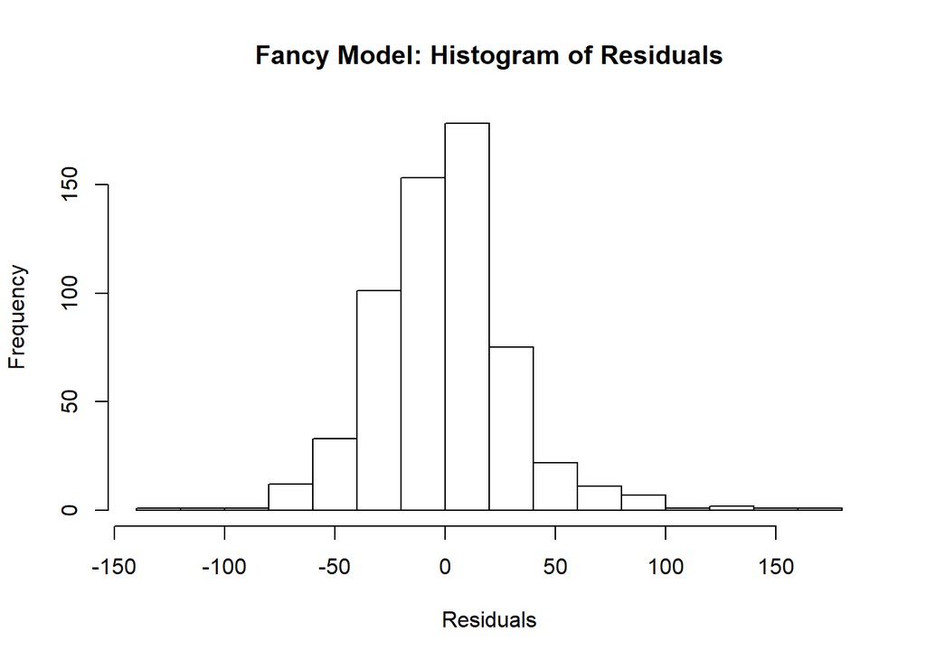

```r
hist(modelFancy$residuals, breaks=15, main="Fancy Model: Histogram of Residuals", xlab="Residuals")
```

Same as before, the distribution of the error is centered at zero. Points are randomly scattered above and below the line, as illustrated by the histogram and residual vs fitted plot.

There is still some pattern in the distribution of the reisudals, yet less curved pattern indicates there is a slight improvement in fit.

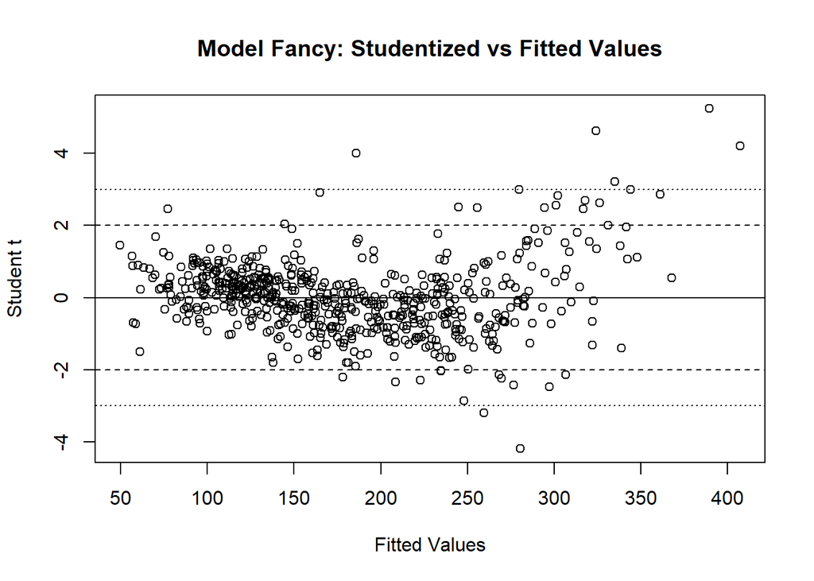

```r
r_student_fancy <- rstudent(modelFancy)

plot(r_student_fancy ~ modelFancy$fitted.values,  main="Model Fancy: Studentized vs Fitted Values", xlab="Fitted Values", ylab="Student t")
abline(0,0)
abline(2,0, lty=2)
abline(-2,0, lty=2)
abline(3,0, lty=3)
abline(-3,0, lty=3)
```

Again, couple of residuals are away from the center.

Overall,residuals seem closely normally distributed, yet there persists a little right skewness in the distribution of residuals, even after transformation to the fancy model..

** PART 5 **

```r
summary(modelFancy)
```

```
##
## Call:
## lm(formula = Price ~ I(BasementFBath + BasementHBath * 0.5 +
##     FullBath + HalfBath * 0.5) + I(WoodDeckSF + OpenPorchSF +
##     EnclosedPorchSF + ScreenPorchSF) + LotFrontage + LotArea +
##     I(1/(2019 - YearBuilt)) + I(1/(2019 - YearRemodel)) + BasementSF +
##     GroundSF + Bedroom + GarageSF, data = HomeData)
##
## Residuals:
##      Min       1Q   Median       3Q      Max
## -130.666  -19.071   -0.241   16.453  162.440
##
## Coefficients:
##                                                                      Estimate
## (Intercept)                                                        -3.033e+01
## I(BasementFBath + BasementHBath * 0.5 + FullBath + HalfBath * 0.5)  8.971e+00
## I(WoodDeckSF + OpenPorchSF + EnclosedPorchSF + ScreenPorchSF)       3.713e-02
## LotFrontage                                                         8.012e-02
## LotArea                                                             4.446e-04
## I(1/(2019 - YearBuilt))                                             7.091e+02
## I(1/(2019 - YearRemodel))                                           2.824e+02
## BasementSF                                                          4.205e-02
## GroundSF                                                            5.964e-02
## Bedroom                                                            -7.558e+00
## GarageSF                                                            5.376e-02
##                                                                    Std. Error
## (Intercept)                                                         6.500e+00
## I(BasementFBath + BasementHBath * 0.5 + FullBath + HalfBath * 0.5)  2.433e+00
## I(WoodDeckSF + OpenPorchSF + EnclosedPorchSF + ScreenPorchSF)       8.788e-03
## LotFrontage                                                         4.164e-02
## LotArea                                                             1.069e-04
## I(1/(2019 - YearBuilt))                                             1.010e+02
## I(1/(2019 - YearRemodel))                                           9.023e+01
## BasementSF                                                          4.146e-03
## GroundSF                                                            4.318e-03
## Bedroom                                                             2.111e+00
## GarageSF                                                            7.836e-03
##                                                                    t value
## (Intercept)                                                         -4.667
## I(BasementFBath + BasementHBath * 0.5 + FullBath + HalfBath * 0.5)   3.687
```

[output cut: 24 more lines]

```
## I(WoodDeckSF + OpenPorchSF + EnclosedPorchSF + ScreenPorchSF)      ***
## LotFrontage                                                        .
## LotArea                                                            ***
## I(1/(2019 - YearBuilt))                                            ***
## I(1/(2019 - YearRemodel))                                          **
## BasementSF                                                         ***
## GroundSF                                                           ***
## Bedroom                                                            ***
## GarageSF                                                           ***
## ---
## Signif. codes:  0 '***' 0.001 '**' 0.01 '*' 0.05 '.' 0.1 ' ' 1
##
## Residual standard error: 32.29 on 589 degrees of freedom
## Multiple R-squared:  0.821,  Adjusted R-squared:  0.8179
## F-statistic: 270.1 on 10 and 589 DF,  p-value: < 2.2e-16
```

```r
HouseDataFrame = data.frame(BasementFBath=0,BasementHBath=0,FullBath=2,HalfBath=1,WoodDeckSF=0,OpenPorchSF=274,EnclosedPorchSF=0,ScreenPorchSF=0,LotFrontage=90,LotArea=11060,YearBuilt=1995,YearRemodel=2003,BasementSF=1150,GroundSF=2314,Bedroom=3,GarageSF=502)

predict.lm(modelFancy, HouseDataFrame, interval="prediction", level=.95)
```

```
##        fit      lwr      upr
## 1 252.2772 188.4965 316.0578
```

** The fit price given by the model for this house is $252,277.20 Based on the prediction interval, there is a 95% chance that the true price of this house lies between $188,496.50 and $316,057.80 **